# Practical H

Gerko Vink

Statistical Programming in R

We use the following packages:

```r
library(ggplot2)
library(dplyr)
```

#### Exercises

Again, just like last time it is wise to start with fixing the random seed.

```r
set.seed(123)
```

1. **Generate two random samples of 10 numbers from a normal distribution with the below specifications. Test the null hypothesis that the population mean is 0.**
- $\mu = 0$ and $\sigma = 2$
- $\mu = 1.5$ and $\sigma = 2$

```r
x <- rnorm(10, mean = 0, sd = 2)
t.test(x)
```

```
##
##  One Sample t-test
##
## data:  x
## t = 0.24742, df = 9, p-value = 0.8101
## alternative hypothesis: true mean is not equal to 0
## 95 percent confidence interval:
##  -1.215341  1.513843
## sample estimates:
## mean of x
## 0.1492513
```

```r
x <- rnorm(10, 1.5, 2)
t.test(x)
```

```
##
##  One Sample t-test
##
## data:  x
## t = 2.9202, df = 9, p-value = 0.01703
## alternative hypothesis: true mean is not equal to 0
## 95 percent confidence interval:
##  0.432058 3.402430
## sample estimates:
## mean of x
##  1.917244
```

2. **Write a function that generates a random sample of `n` numbers from a normal distribution with a user defined mean (i.e. a mean that you can choose when running the function) and standard deviation 1, and returns the `p.value` for the test that the mean is 0.**

```r
p.value.t <- function (n, mu) {
  x <- rnorm(n, mu, 1)
  t.test(x)$p.value
}

p.value.t(n = 30, mu = 3)
```

```
## [1] 2.912617e-17
```

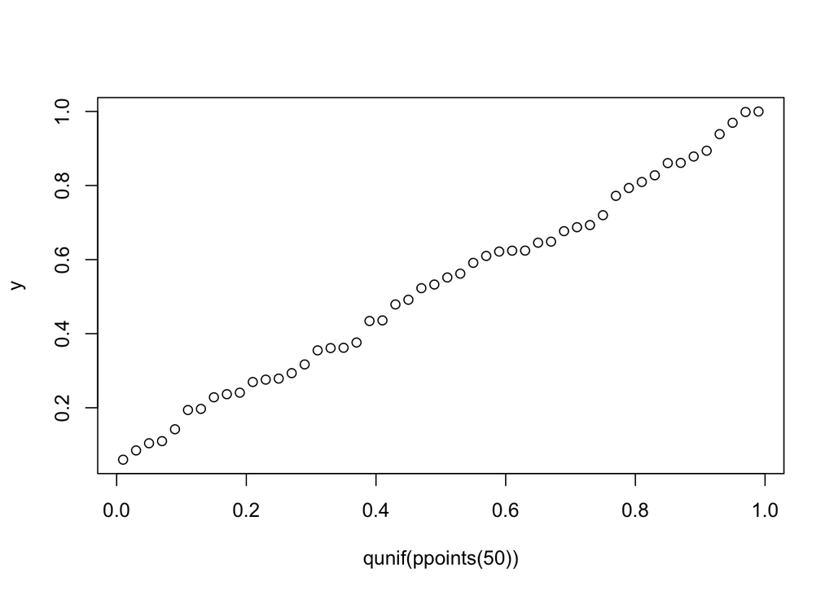

```r
y <- numeric(50)
for (i in 1:50) {
  y[i] <- p.value.t(n = 10, mu = 0)
}

qqplot(x=qunif(ppoints(50)), y)
```

The p-values follow a uniform distribution.

In a study that examined the use of acupuncture to treat migraine headaches, consenting patients on a waiting list for treatment for migraine were randomly assigned in a 2:1:1 ratio to acupuncture treatment, a “sham” acupuncture treatment in which needles were inserted at non-acupuncture points, and waiting-list patients whose only treatment was self-administered (Linde et al., 2005). The “sham” acupuncture treatment was described to trial participants as an acupuncture treatment that did not follow the principles of Chinese medicine.

4. **What is the conclusion when the outcome is classified according to numbers of patients who experienced a greater than 50% reduction in headaches over a four-week period, relative to a pre-randomization baseline?**

Use the following data

```r
data <- matrix(c(74, 71, 43, 38, 11, 65), nrow = 2, ncol = 3)
colnames(data) <- c("Acupuncture", "Sham", "Waiting list")
rownames(data) <- c("> 50% reduction", "< 50% reduction")
data
```

```
##                 Acupuncture Sham Waiting list
## > 50% reduction          74   43           11
## < 50% reduction          71   38           65
```

We start with calculating the $X^2$-test:

```r
X2test <-
  data %>%
  chisq.test()

X2test
```

```
##
##  Pearson's Chi-squared test
##
## data:  .
## X-squared = 32.486, df = 2, p-value = 8.825e-08
```

which is extremely significant. We can then calculate the expected cell frequencies

```r
X2test$expected
```

```
##                 Acupuncture     Sham Waiting list
## > 50% reduction    61.45695 34.33113     32.21192
## < 50% reduction    83.54305 46.66887     43.78808
```

and the raw residual

```r
X2test$observed - X2test$expected
```

```
##                 Acupuncture      Sham Waiting list
## > 50% reduction    12.54305  8.668874    -21.21192
## < 50% reduction   -12.54305 -8.668874     21.21192
```

as well as the Pearson residual

```r
X2test$residuals
```

```
##                 Acupuncture      Sham Waiting list
## > 50% reduction    1.599991  1.479513    -3.737418
## < 50% reduction   -1.372296 -1.268963     3.205546
```

to infer the difference in observed and expected cell frequencies. Patients on the waiting list experience `> 50% reduction` much less than we would expect under independence of treatment and outcome.

5. **Patients who received the acupuncture and sham acupuncture treatments were asked to guess their treatment at the end of their trial. What would you conclude from this data?**

```r
data <- matrix(c(82, 17, 30, 30, 26, 16), nrow = 3, ncol = 2)
colnames(data) <- c("Acupuncture", "Sham")
rownames(data) <- c("Chinese", "Other", "Don't know")
data
```

```
##            Acupuncture Sham
## Chinese             82   30
## Other               17   26
## Don't know          30   16
```

We again start with calculating the $X^2$-test:

```r
X2test <-
  data %>%
  chisq.test()

X2test
```

```
##
##  Pearson's Chi-squared test
##
## data:  .
## X-squared = 15.358, df = 2, p-value = 0.0004624
```

which is very significant. We can then calculate the expected cell frequencies

```r
X2test$expected
```

```
##            Acupuncture     Sham
## Chinese       71.88060 40.11940
## Other         27.59701 15.40299
## Don't know    29.52239 16.47761
```

and the raw residual

```r
X2test$observed - X2test$expected
```

```
##            Acupuncture        Sham
## Chinese     10.1194030 -10.1194030
## Other      -10.5970149  10.5970149
## Don't know   0.4776119  -0.4776119
```

as well as the Pearson residual

```r
X2test$residuals
```

```
##            Acupuncture       Sham
## Chinese     1.19357319 -1.5976353
## Other      -2.01721641  2.7001078
## Don't know  0.08790214 -0.1176598
```

We find that people who are receiving *true* `Acupuncture` are more inclined to believe that they receive `Chinese` acupuncture than we would expect under independence, while people wo received `Sham` acupuncture are more inclined to believe that they receive `Other` type of acupuncture. `Don't know` is more or less similarly distributed over the observed and expected frequencies.

In the following simulation experiment we investigate least-squares estimation of the mean.

6. **Start by drawing a 100 values from a normal distribution with $\mu = 3$ and $\sigma = 7$. Use seed value `32083`.**

```r
set.seed(32083)

x <- rnorm(100, mean=3, sd=7)
```

7. **Next, confirm that the sample mean of the values in x is near 4.166.**

```r
mean(x)
```

```
## [1] 4.165695
```

8. **Calculate the sample mean’s sum of squared deviations from $\mu$. The sum of squared deviations from mu is defined as:**
   $$\sum_{i=1}^{100} (x_i - \mu)^2,$$
   There is a slow way

```r
mu = 3
summed <- x-mu
sum.sq <- sum(summed^2)
```

And a fast way

```r
sum.sq2 <- apply(outer(x, mu, "-")^2, 2, sum)
```

Both solutions are identical

```r
identical(sum.sq, sum.sq2)
```

```
## [1] TRUE
```

9. **Now create a function that automates the calculation of the sum of squares for any given $\mu$. Call the function `lsfun` because we are going to identify the least squares estimate in exercise 8.**

```r
lsfun <- function(meanest) apply(outer(x, meanest, "-")^2, 2, sum)
```

or, 100% equivalently, but easier to spot as a function:

```r
lsfun <- function(meanest){
  apply(outer(x, meanest, "-")^2, 2, sum)
}
```

10. **Plot the curve of your least square function such that you can identify the minimum of the curve (i.e. the location for $x$ where the sum of the squared deviations are the lowest).**

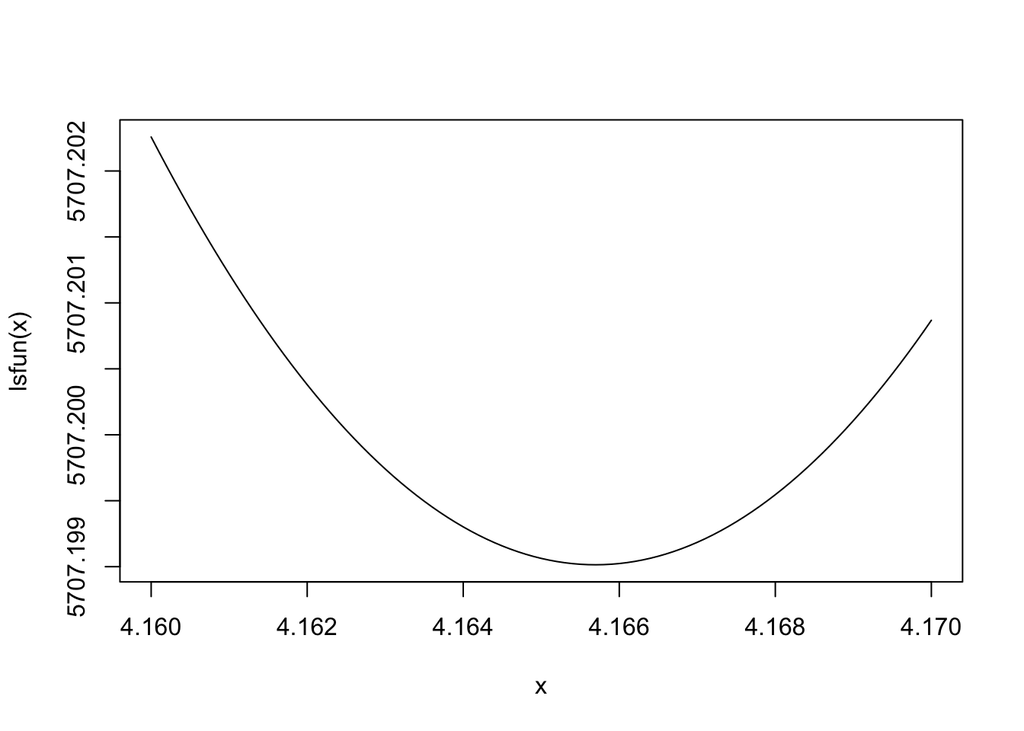

```r
curve(lsfun, from = 4.16, to = 4.17)
```

11. **Repeat the experiment from 10 with the following $X \sim \mathcal{N}(\mu, \sigma^2)$ normal samples of length $n=100$, but now use the sample mean $\bar{x}$ in your function `lsfun()`. Let the function plot the curve and print the location where the minimum of the sum of the squares is located each time. Fix the seed to `set.seed(123)`:**
- $x \sim \mathcal{N}(3, 7)$
- $x \sim \mathcal{N}(15, 12)$
- $x \sim \mathcal{N}(0, 2)$
- $\sqrt{x} \sim \mathcal{N}(0, 2)$, i.e. you need to square $x$

Hint: use the sample mean $\bar{x}$ as the center of your graph and add/subtract e.g. `.5` from this value to plot a range.

First, we fix the random seed

```r
set.seed(123)
```

Code-wise it is efficient to write a function that does the repetitive experimentation. That way we have to write some lines of code only once.

```r
plotfun <- function(x, meanest, plot = TRUE){
  xbar <- mean(x)
  lsfun <- function(meanest){ apply(outer(xbar, meanest, "-")^2, 2, sum)}
  # lsfun <- function(mu, xbar) {
  #   summed <- x-mu
  #   sum.sq <- sum(summed^2)
  #   return(sum.sq)
  # }
  if (plot) {
    curve(lsfun, from = xbar - .5, to = xbar + .5,
          ylab=expression(paste(Sigma," ",e^2))) #nicer y-axis label
  }
  return(cat("The mean is:", xbar, "\n"))
}
```

- For $x \sim \mathcal{N}(3, 7)$:

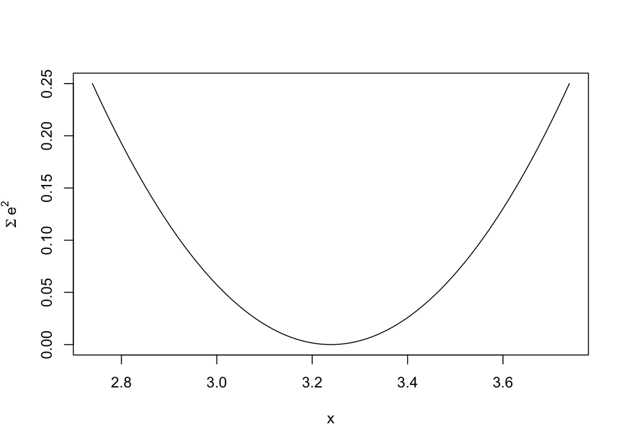

```
## The mean is: 3.239192
```

```r
rnorm(100, mean=3, sd=sqrt(7)) %>%
  plotfun(meanest = 3, plot = TRUE)
```

- For $x \sim \mathcal{N}(15, 12)$

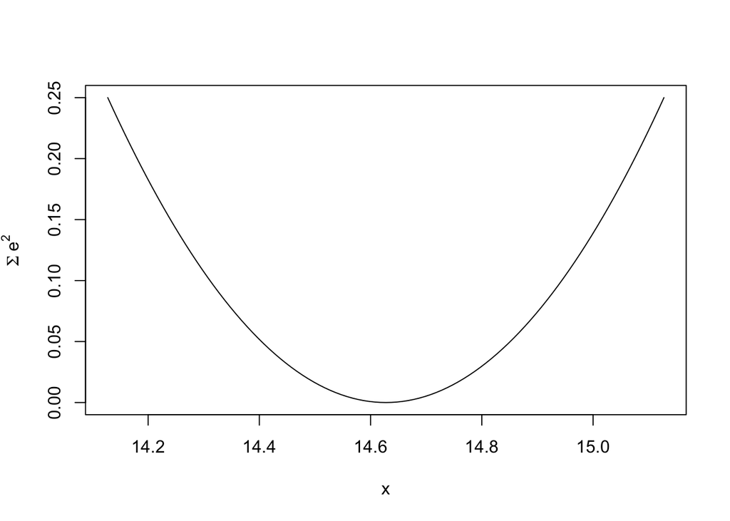

```
## The mean is: 14.62745
```

```r
rnorm(100, mean=15, sd=sqrt(12)) %>%
  plotfun(meanest = 15, plot = TRUE)
```

- For $x \sim \mathcal{N}(0, 2)$:

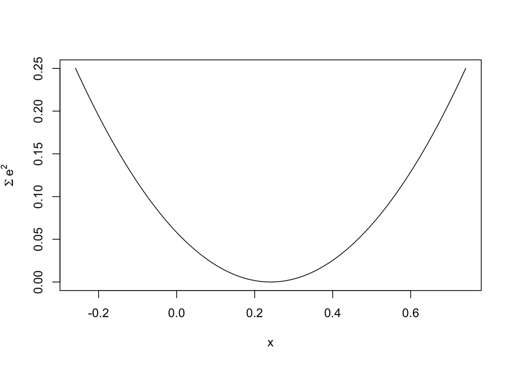

```
## The mean is: 0.2409302
```

```r
rnorm(100, mean=0, sd=2) %>%
  plotfun(meanest = 0, plot = TRUE)
```

- For $\sqrt{x} \sim \mathcal{N}(0, 2)$:

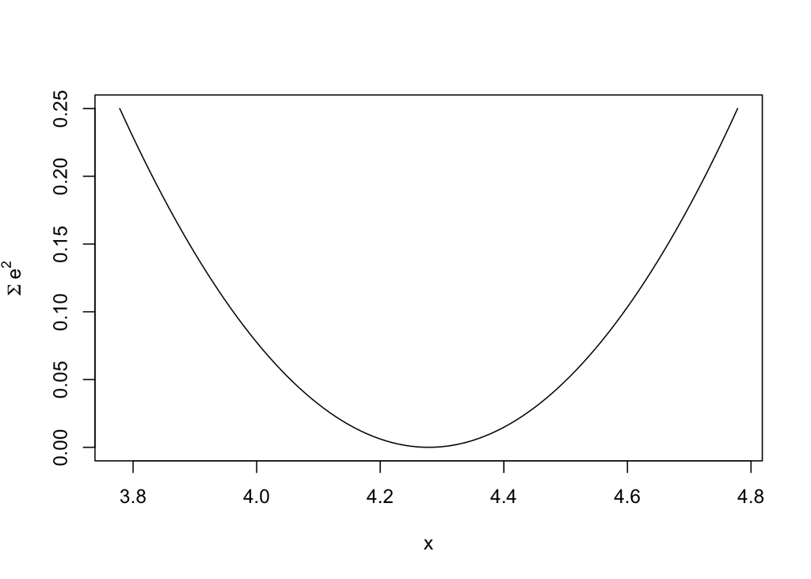

```
## The mean is: 4.278351
```

```r
rnorm(100, mean=0, sd=2)^2 %>%
  plotfun(meanest = 0, plot = TRUE)
```

End of practical.